# Practice Code: Day 1

Author

Constantin Manuel Bosancianu

Published

July 31, 2017

# 1 Introduction

The data for today refers to the average SAT level in each of the 51 American states, and what it is impacted by. The example scales easily to other settings, such as comparisons between countries in the PISA rankings, or between schools within a decentralized education system. The data comes from @hamilton_statistics_2006, in a Stata format. It originates from data collected around 1990-1991.

It’s important to keep the data small, as we can easily identify in a small data set which are the outliers, and understand what is so particular about them. This is rarely the case with a large-N data set.

**Warning**: the code chunk below will install packages on your system (if these are not already installed).

```r
library(pacman)
p_load(readstata13, tidyverse, lmtest, MASS, car, texreg, knitr,
       kableExtra, magrittr, ggthemes, effects, corrgram)

options(scipen = 8) # Avoid scientific notation for coefficients
```

The `p_load()` function from the `pacman` package looks for the collection of packages you specify on your machine. If it finds them, it loads them in the working environment; if it doesn’t, it downloads them, installs them, and then loads them.

# 2 Reading data

The code chunk below assumes that the data set is in the `02-data` folder. This means we have to go one folder up from the code folder, and then into the data folder.

```r
df_sat <- read.dta13(file = "../02-data/11-Education-states.dta",
                     convert.factors = TRUE)
```

```r
fun_cent <- function(x) {
    x - mean(x, na.rm = TRUE)
}
```

We will be using a lot of functions from the `dplyr` package and from some of the other packages that make up the `tidyverse`. Despite some opinions to the contrary (https://github.com/matloff/TidyverseSkeptic), I believe it is a very elegant way of thinking about coding, and one which I think will grow in importance. It pays off to learn it early and well.

The pipe operator (`%>%`) serves to take the output from a line of code, and feed it as input into the next line of code. It can be loosely translated as “with this… do that…”.

```r
df_sat %>%
    glimpse()
```

```
Rows: 51
Columns: 18
$ state   <chr> "Alabama", "Alaska", "Arizona", "Arkansas", "California", "Col…
$ region  <fct> South, West, West, South, West, West, N. East, South, NA, Sout…
$ pop     <dbl> 4041000, 550000, 3665000, 2351000, 29760000, 3294000, 3287000,…
$ area    <dbl> 52423, 570374, 113642, 52075, 155973, 103730, 4845, 1955, NA, …
$ density <dbl> 77.08, 0.96, 32.25, 45.15, 190.80, 31.76, 678.43, 340.66, NA, …
$ metro   <dbl> 67.4, 41.1, 79.0, 40.1, 95.7, 81.5, 92.4, 66.3, NA, 90.8, 65.0…
$ waste   <dbl> 1.11, 0.91, 0.79, 0.85, 1.51, 0.73, 0.88, 1.13, NA, 1.45, 0.68…
$ energy  <int> 393, 991, 258, 330, 246, 273, 234, 349, NA, 237, 322, 243, 354…
$ toxic   <dbl> 27.86, 37.41, 19.65, 24.60, 3.26, 2.25, 6.49, 9.88, NA, 8.24, …
$ green   <dbl> 29.25, NA, 18.37, 26.04, 15.65, 21.89, 14.63, 21.53, NA, 13.57…
$ csat    <int> 991, 920, 932, 1005, 897, 959, 897, 892, 840, 882, 844, 883, 9…
$ vsat    <int> 476, 439, 442, 482, 415, 453, 429, 428, 405, 416, 400, 405, 46…
$ msat    <int> 515, 481, 490, 523, 482, 506, 468, 464, 435, 466, 444, 478, 50…
$ percent <int> 8, 41, 26, 6, 47, 29, 81, 61, 71, 48, 62, 55, 18, 16, 57, 5, 1…
$ expense <int> 3627, 8330, 4309, 3700, 4491, 5064, 7602, 5865, 9259, 5276, 44…
$ income  <dbl> 27.498, 48.254, 32.093, 24.643, 41.716, 35.123, 48.618, 40.641…
$ high    <dbl> 66.9, 86.6, 78.7, 66.3, 76.2, 84.4, 79.2, 77.5, 73.1, 74.4, 70…
$ college <dbl> 15.7, 23.0, 20.3, 13.3, 23.4, 27.0, 27.2, 21.4, 33.3, 18.3, 19…
```

# 3 Codebook

A few of the most important variables

1. `pop`: poppulation
2. `density`: population density per square mile
3. `csat`: mean composite SAT score
4. `expense`: primary & secondary expenditure per pupil
5. `percent`: % of HS graduates taking SAT
6. `income`: median HH income, in 1000s
7. `high`: % of adults with HS diploma
8. `college`: % of adults with college degree
9. `region`: geographical region

# 4 Initial model

I will start off by exploring a very simple model with 2 continuous predictors and a dichotomous one. First, I want to rescale the variables, to make sure that the intercept is not interpreted in an absurd way.

I also generate an indicator variable for the region in which the state is located. For this particular regression, I distinguish between the Northeast of the US (including District of Columbia), and everywhere else.

```r
df_sat %<>%
    mutate(exp_scale = fun_cent(expense),
           per_scale = fun_cent(percent),
           region = as.character(region)) %>%
    mutate(neast = if_else(region == "N. East", 1, 0),
           neast = if_else(state == "District of Columbia", 1, neast),
           neast = as.factor(neast))
```

```r
model1 <- lm(csat ~ exp_scale + per_scale + neast,
             data = df_sat,
             na.action = na.omit)

summary(model1)
```

```
Call:
lm(formula = csat ~ exp_scale + per_scale + neast, data = df_sat,
    na.action = na.omit)

Residuals:
    Min      1Q  Median      3Q     Max
-61.363 -19.619  -3.207  17.008  72.165

Coefficients:
              Estimate Std. Error t value Pr(>|t|)
(Intercept) 934.891177   5.114180 182.804  < 2e-16 ***
exp_scale     0.003477   0.004248   0.819  0.41718
per_scale    -2.856530   0.233554 -12.231 3.28e-16 ***
neast1       46.954995  15.606341   3.009  0.00421 **
---
Signif. codes:  0 '***' 0.001 '**' 0.01 '*' 0.05 '.' 0.1 ' ' 1

Residual standard error: 29.26 on 47 degrees of freedom
Multiple R-squared:  0.8203,    Adjusted R-squared:  0.8089
F-statistic: 71.53 on 3 and 47 DF,  p-value: < 2.2e-16
```

You can easily export this output in a format that makes it easy to include the results in a paper, with the help of the `htmlreg()` or `texreg()` functions from the `texreg` package.

```r
htmlreg(list(model1), # List of models - here we have only 1
        file = "../06-output/Table-1.html", # output file
        custom.model.names = c("DV: CSAT"), # custom names for models
        custom.coef.names = c("(Intercept)", "Educ. expense",
                              "% SAT takers", "Northeast & DC"), # custom variable names
        digits = 3, # decimal places for coefficients and SEs
        single.row = FALSE) # display BETA and SEs under each other

# It can also export in LaTeX format, if need be
texreg(list(model1), # List of models - here we have only 1
       file = "../06-output/Table-1.tex", # output file
       custom.model.names = c("DV: CSAT"), # custom names for models
       custom.coef.names = c("(Intercept)", "Educ. expense",
                             "% SAT takers", "Northeast & DC"), # custom variable names
       digits = 3, # decimal places for coefficients and SEs
       single.row = FALSE, # display BETA and SEs under each other
       booktabs = TRUE, # Assume package for nice borders is present
       dcolumn = TRUE, # Assume package for decimal point alignment is present
       use.packages = FALSE) # Do not include these packages
```

Instead of displaying coefficients, you might want to use a visual presentation of the effects of variables. There are many packages for this, but the `effects` package is a simple and fairly powerful one.

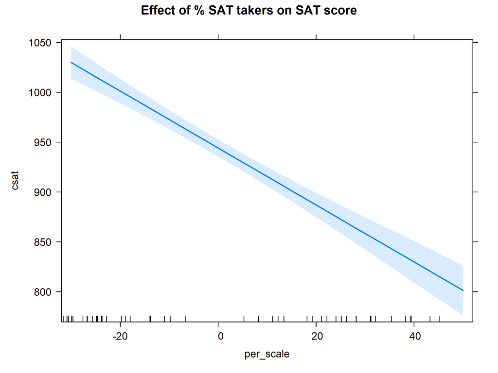

```r
plot(Effect(focal.predictors = "per_scale", # What is the predictor of interest?
            mod = model1, # The model estimates which effect is based on
            xlevels = list(perScale = -20:20)), # Range of the predictor of
                                     # interest, for presenting effects
     main = "Effect of % SAT takers on SAT score") # Figure headline
```

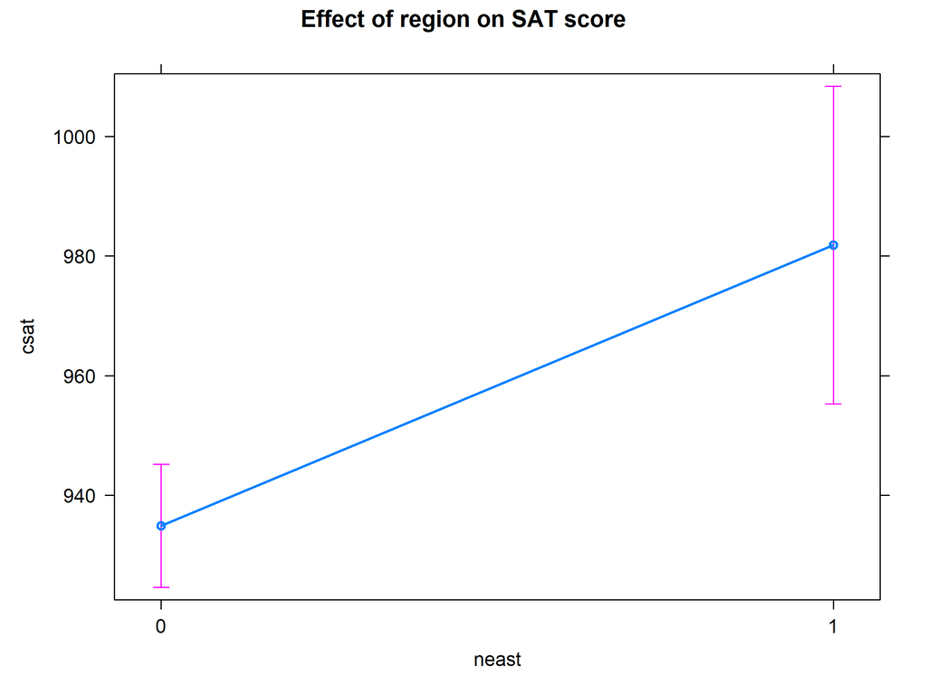

```r
# It also works for dichotomous predictors
plot(Effect(focal.predictors = "neast",
            mod = model1,
            xlevels = list(neast=c(0,1))),
     main = "Effect of region on SAT score")
```

Let’s turn to our assumptions, though…

# 5 Linearity

We have to produce a component-plus-residual plot.

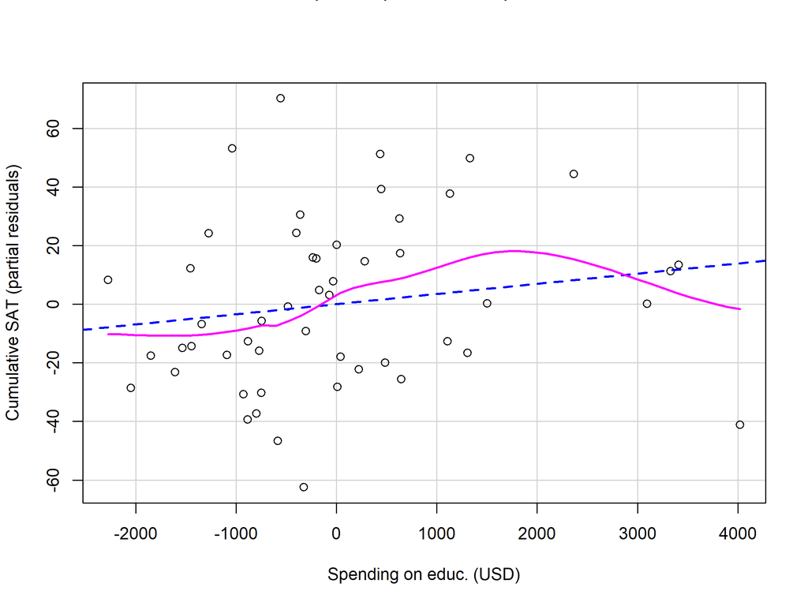

```r
crPlots(model1, "exp_scale",
        main = "Component-plus-residual plot",
        xlab = "Spending on educ. (USD)",
        ylab = "Cumulative SAT (partial residuals)")
```

It’s maybe a bit of a stretch to call this a linear relationship, but given that it’s a small sample, it’s perhaps reasonably close to a linear one. Let’s see what the other diagnostics tell us before we make a decision in this case.

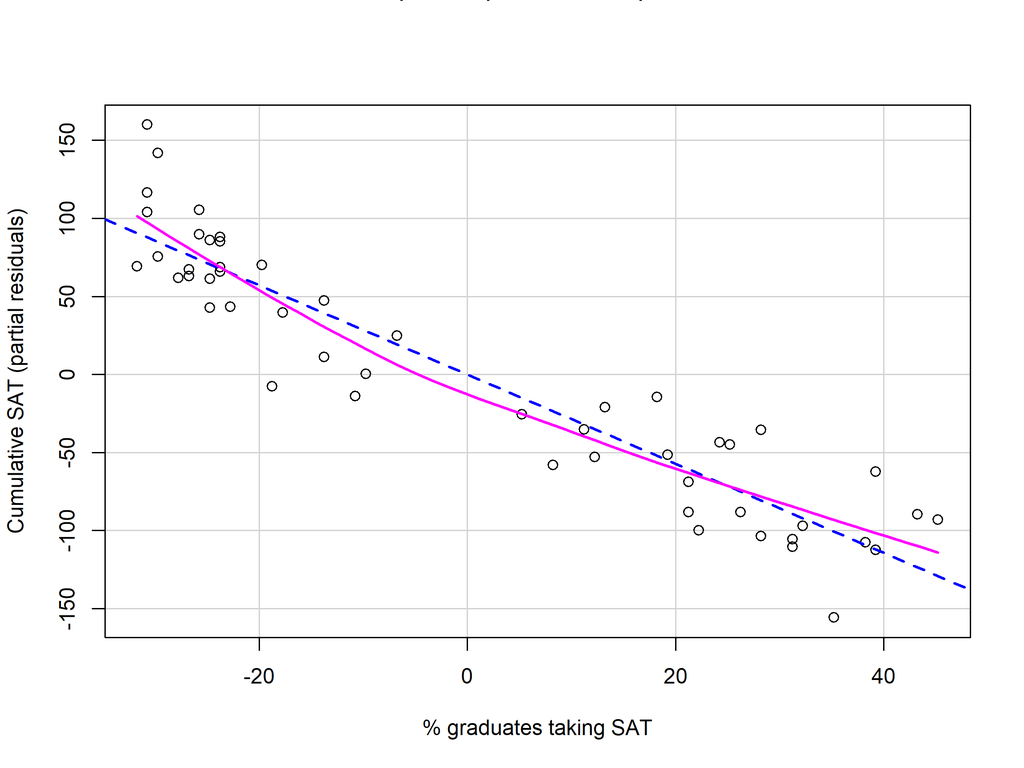

```r
crPlots(model1, "per_scale",
        main = "Component-plus-residual plot",
        xlab = "% graduates taking SAT",
        ylab = "Cumulative SAT (partial residuals)")
```

# 6 Homoskedasticity

First, a plot of fitted values (Y-hat) against studentized residuals.[^1]

<sup>1</sup> We use the `studres()` function from the `MASS` package for this.

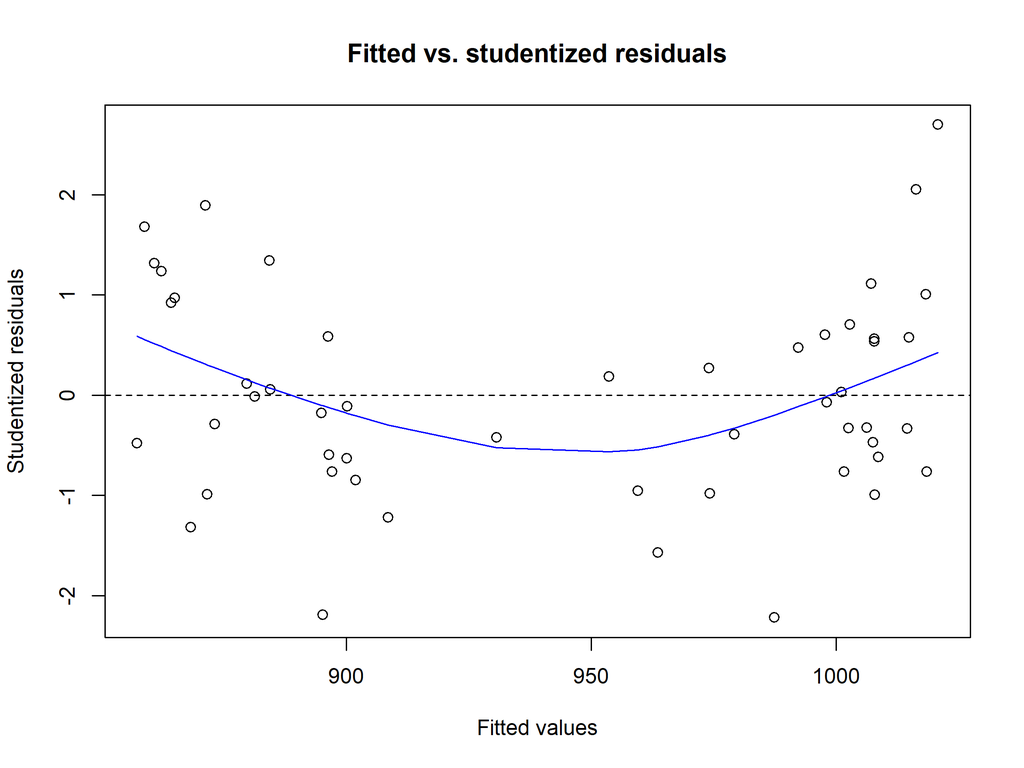

```r
plot(fitted(model1),
     studres(model1),
     xlab = "Fitted values",
     ylab = "Studentized residuals",
     main = "Fitted vs. studentized residuals")
abline(h = 0, lty = 2)
lines(lowess(fitted(model1),
      studres(model1)),
      col = "blue")
```

It’s a small sample size, so I would not automatically say that there is heteroskedasticity.

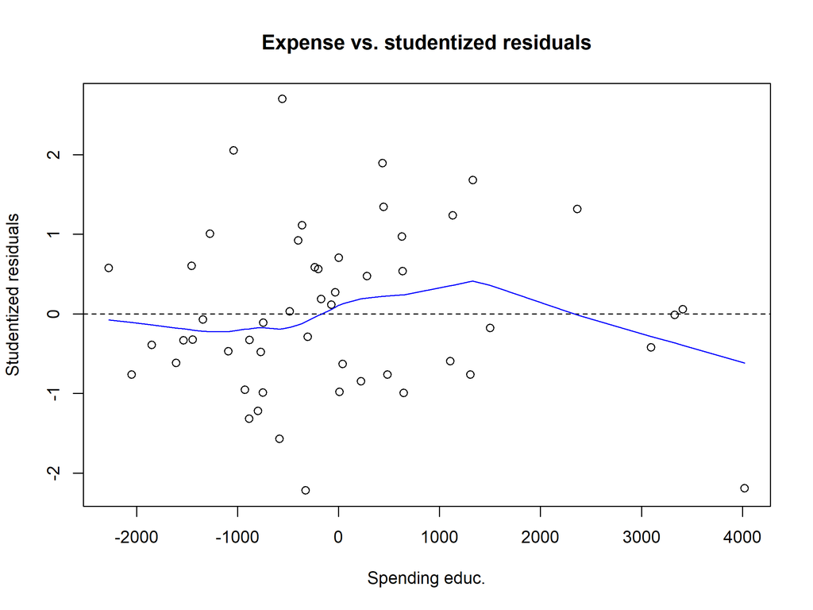

```r
plot(df_sat$exp_scale,
     studres(model1),
     xlab = "Spending educ.",
     ylab = "Studentized residuals",
     main = "Expense vs. studentized residuals")
abline(h = 0, lty = 2)
lines(lowess(df_sat$exp_scale,
      studres(model1)),
      col = "blue")
```

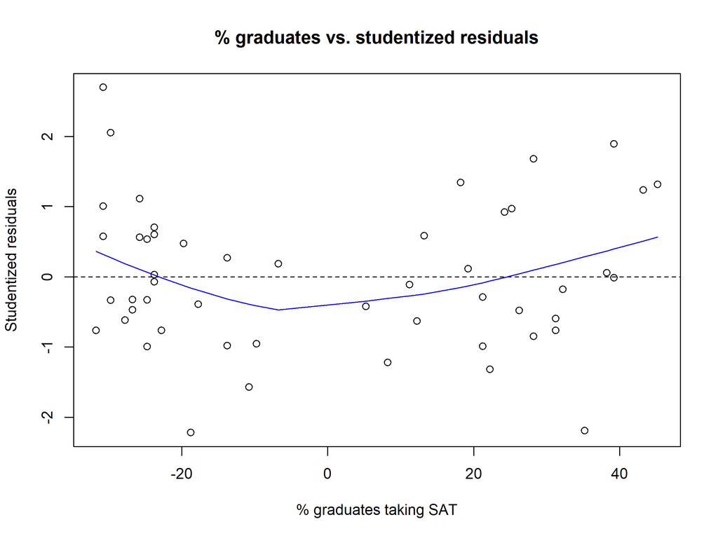

```r
plot(df_sat$per_scale,
     studres(model1),
     xlab = "% graduates taking SAT",
     ylab = "Studentized residuals",
     main = "% graduates vs. studentized residuals")
abline(h = 0, lty = 2)
lines(lowess(df_sat$per_scale,
      studres(model1)),
      col = "blue")
```

# 7 Normality

We would need a quantile comparison plot in this case.

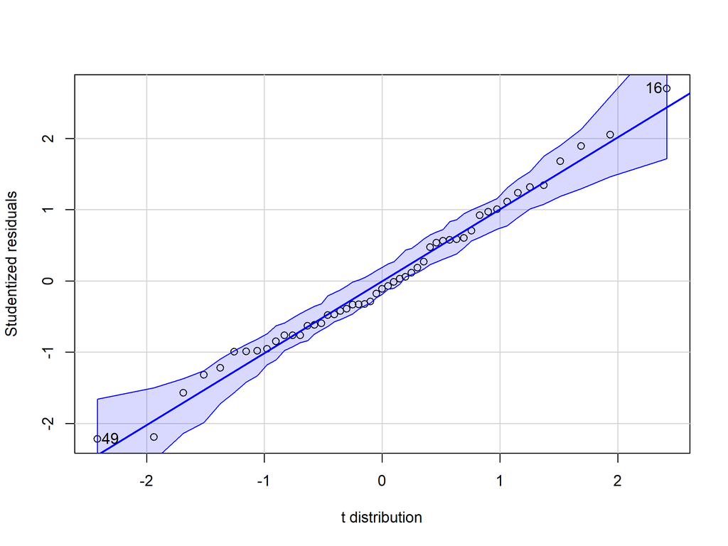

```
[1] 16 49
```

```r
qqPlot(model1, xlab = "t distribution",
       ylab = "Studentized residuals",
       id.method = "identify")
```

At least, overall, everything looks OK in terms of the normal distribution.

# 8 Specification error

What other factors could be influencing average SAT scores? It turns out that a good case can be made for income. With higher average incomes, more can be invested in a child’s education: special tutoring, books etc. At the same time, we might simply be dealing with reverse causality: in places with more capable students companies are interested in moving in and benefitting from the workforce, which means higher salaries.

Let’s assume that it might be the first.

```r
model2 <- lm(csat ~ exp_scale + per_scale + neast + income,
             data = df_sat,
             na.action = na.omit)
summary(model2)
```

```
Call:
lm(formula = csat ~ exp_scale + per_scale + neast + income, data = df_sat,
    na.action = na.omit)

Residuals:
    Min      1Q  Median      3Q     Max
-56.291 -17.814  -2.088  16.253  69.126

Coefficients:
              Estimate Std. Error t value Pr(>|t|)
(Intercept) 834.808010  32.752013  25.489  < 2e-16 ***
exp_scale    -0.003504   0.004514  -0.776 0.441589
per_scale    -3.232833   0.247015 -13.088  < 2e-16 ***
neast1       60.723766  15.033665   4.039 0.000202 ***
income        2.867881   0.928775   3.088 0.003413 **
---
Signif. codes:  0 '***' 0.001 '**' 0.01 '*' 0.05 '.' 0.1 ' ' 1

Residual standard error: 26.92 on 46 degrees of freedom
Multiple R-squared:  0.8512,    Adjusted R-squared:  0.8382
F-statistic: 65.78 on 4 and 46 DF,  p-value: < 2.2e-16
```

There is an effect there, in the direction we expected. We also see that the effect of being in the Northeast of the US becomes stronger. Without this additional control we would have underestimated the SAT scores for Northeastern states.

# 9 Collinearity

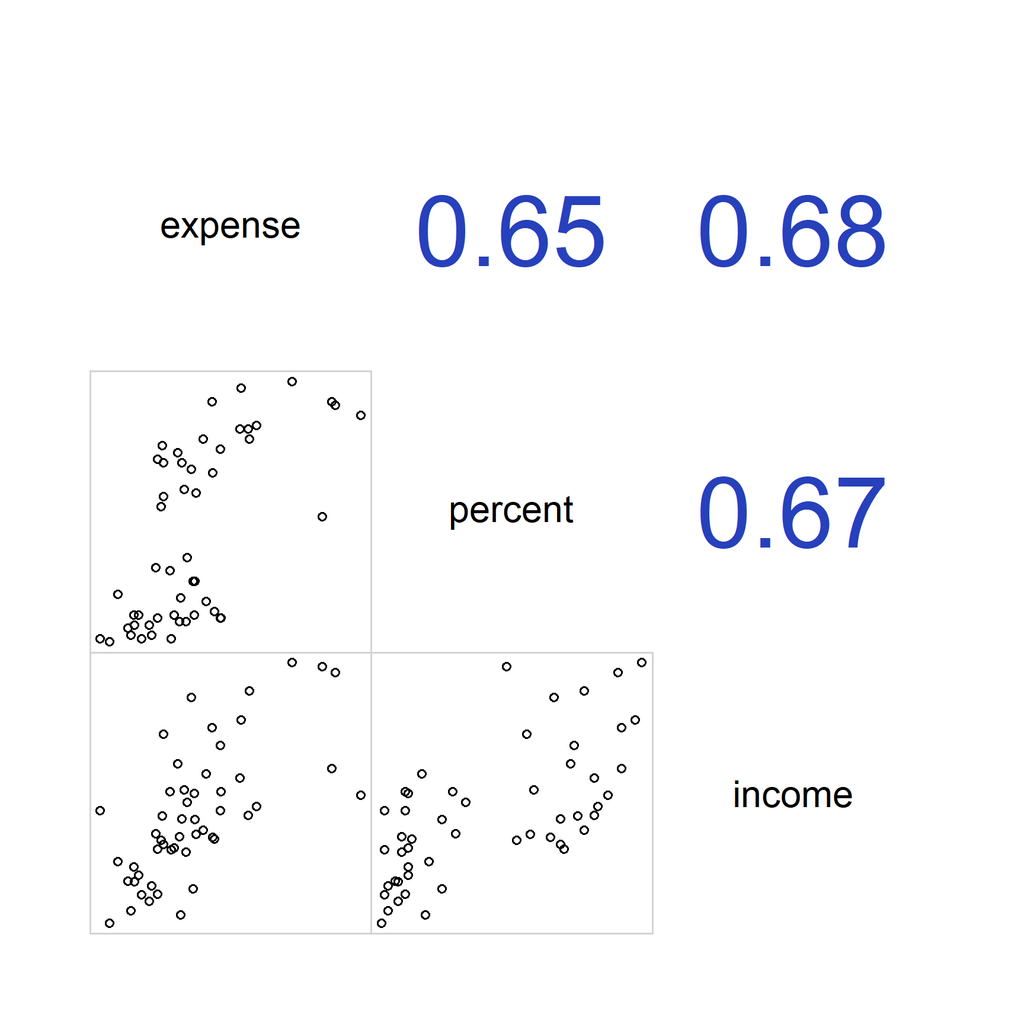

```r
corrgram(df_sat[ ,c("expense", "percent", "income")],
         lower.panel = panel.pts,
         upper.panel = panel.cor)
```

The correlations are pretty high here, but a bit below the threshold mentioned by Fox. In survey-based research you will typically not see such high correlations.

# 10 Solving problems

## 10.1 Variable transformations

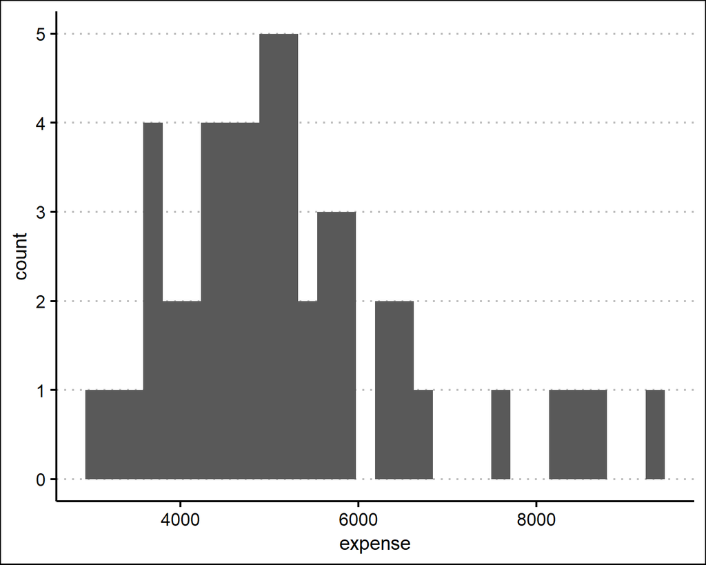

```r
ggplot(df_sat,
       aes(x = expense)) +
    geom_histogram() +
    theme_clean()
```

The distribution is a bit skewed here, which might be responsible for the problems we are seeing in the residuals. I will use a square root transformation.

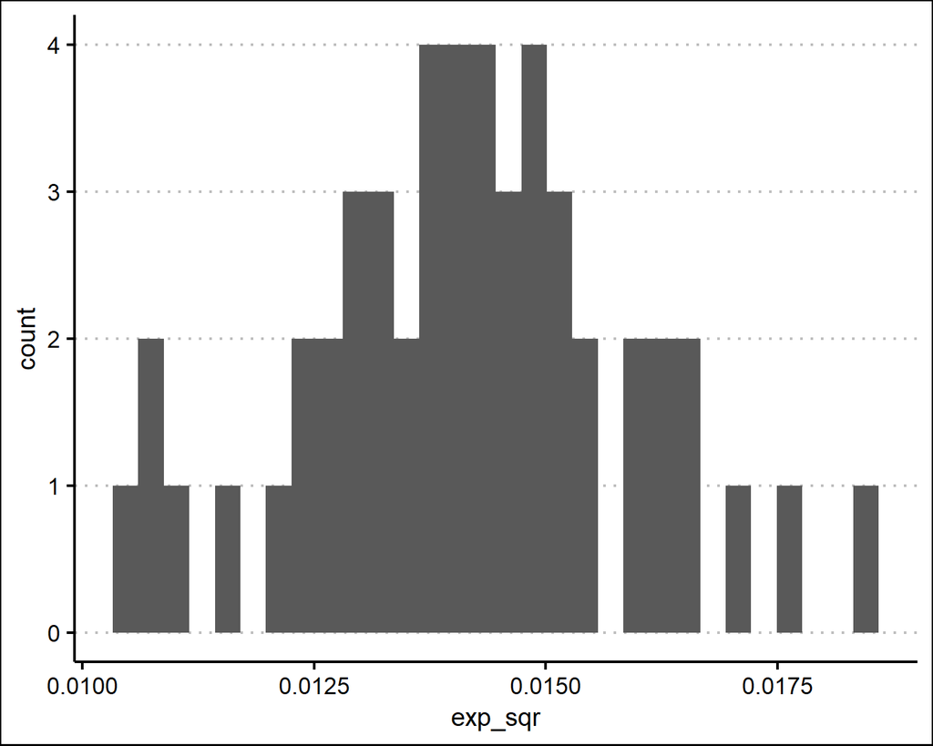

```r
df_sat %<>%
    mutate(exp_sqr = 1 / sqrt(expense))
ggplot(df_sat,
       aes(x = exp_sqr)) +
    geom_histogram() +
    theme_clean()
```

A little bit better, but still not completely normal.

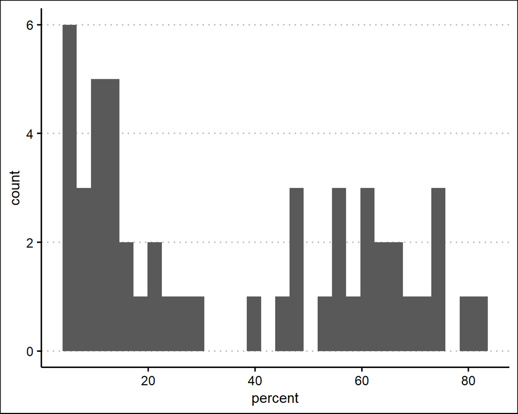

```r
ggplot(df_sat,
       aes(x = percent)) +
    geom_histogram() +
    theme_clean()
```

No transformation can solve this one.

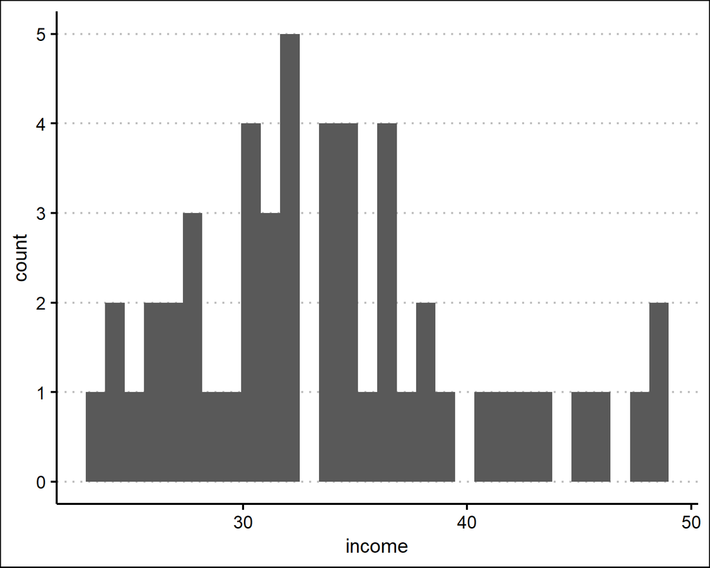

```r
ggplot(df_sat,
       aes(x = income)) +
    geom_histogram() +
    theme_clean()
```

A square root transformation could improve things a bit here as well, from which we take the inverse.

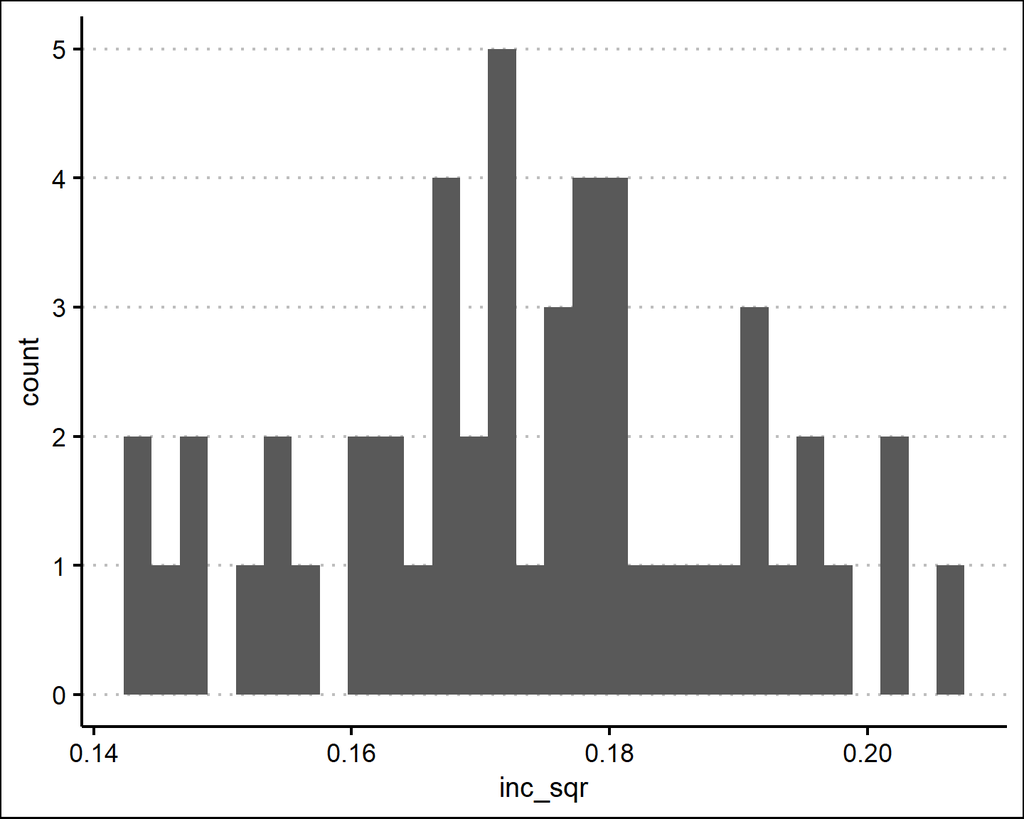

```r
df_sat %<>%
    mutate(inc_sqr = 1 / sqrt(income))
ggplot(df_sat,
       aes(x = inc_sqr)) +
    geom_histogram() +
    theme_clean()
```

There also seemed to be some problem with non-constant error mean in some of the plots that checked for heteroskedasticity.

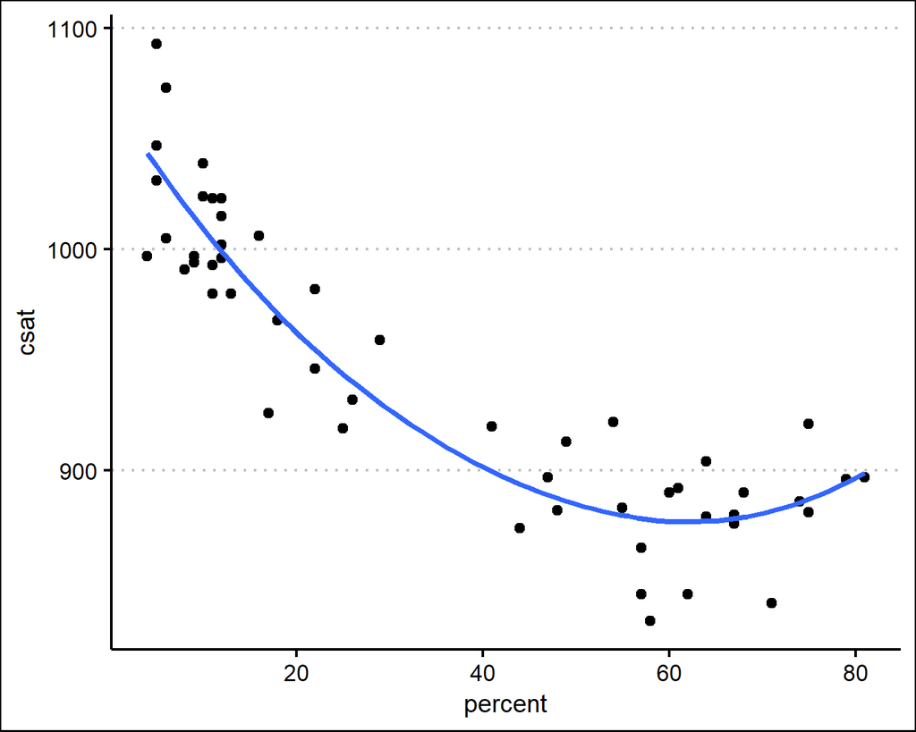

```r
ggplot(df_sat,
       aes(x = percent,
           y = csat)) +
    geom_point() +
    theme_clean() +
    geom_smooth(method = "loess",
                se = FALSE)
```

For `percent`, nothing really gets rid of the non-linearity. The biggest improvement was found for the inverse of the square root, which I used here.

```r
df_sat %<>%
    mutate(perc_sqr = 1 / sqrt(percent))
```

## 10.2 Re-estimating model

So let’s try for the model again, this time with the added `income` predictor, which came out as significant.

```r
model3 <- lm(csat ~ exp_sqr + perc_sqr + neast + inc_sqr,
             data = df_sat,
             na.action = na.omit)
summary(model3)
```

```
Call:
lm(formula = csat ~ exp_sqr + perc_sqr + neast + inc_sqr, data = df_sat,
    na.action = na.omit)

Residuals:
    Min      1Q  Median      3Q     Max
-81.073 -16.827  -1.169  17.881  49.758

Coefficients:
            Estimate Std. Error t value Pr(>|t|)
(Intercept)  1008.17      60.04  16.790  < 2e-16 ***
exp_sqr     -7928.02    3779.93  -2.097   0.0415 *
perc_sqr      639.38      53.60  11.929 1.12e-15 ***
neast1        -19.07      12.92  -1.476   0.1467
inc_sqr      -529.71     378.63  -1.399   0.1685
---
Signif. codes:  0 '***' 0.001 '**' 0.01 '*' 0.05 '.' 0.1 ' ' 1

Residual standard error: 28.59 on 46 degrees of freedom
Multiple R-squared:  0.8322,    Adjusted R-squared:  0.8176
F-statistic: 57.04 on 4 and 46 DF,  p-value: < 2.2e-16
```

Some of the coefficients are different than before, but this is understandable given that we have changed the scale of measurement for some of these predictors.

Now we go through the checks again, starting with heteroskedasticity.

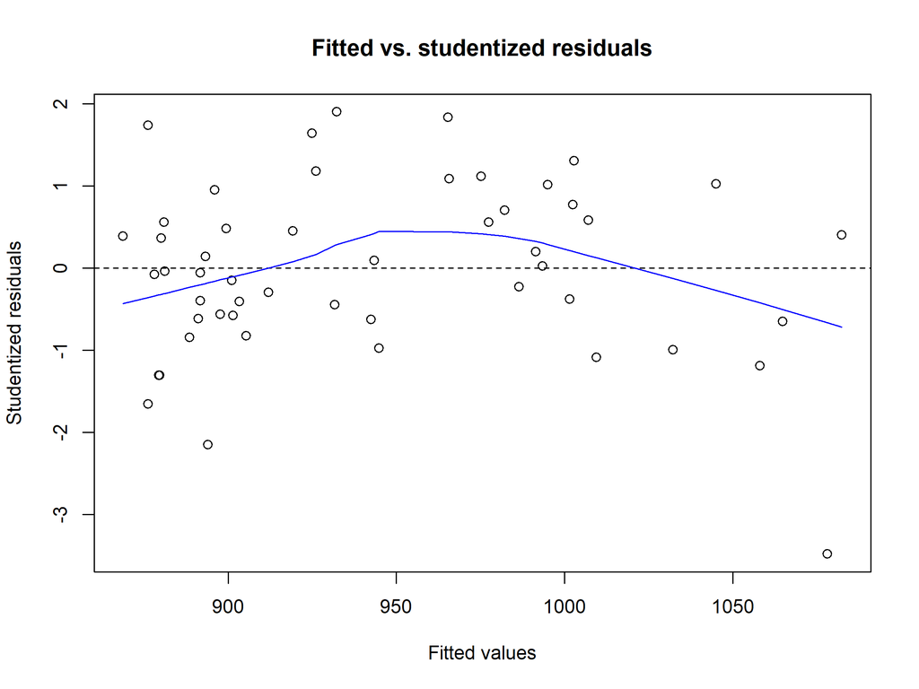

```r
plot(fitted(model3), studres(model3),
     xlab = "Fitted values",
     ylab = "Studentized residuals",
     main = "Fitted vs. studentized residuals")
abline(h = 0, lty = 2)
lines(lowess(fitted(model3), studres(model3)), col = "blue")
```

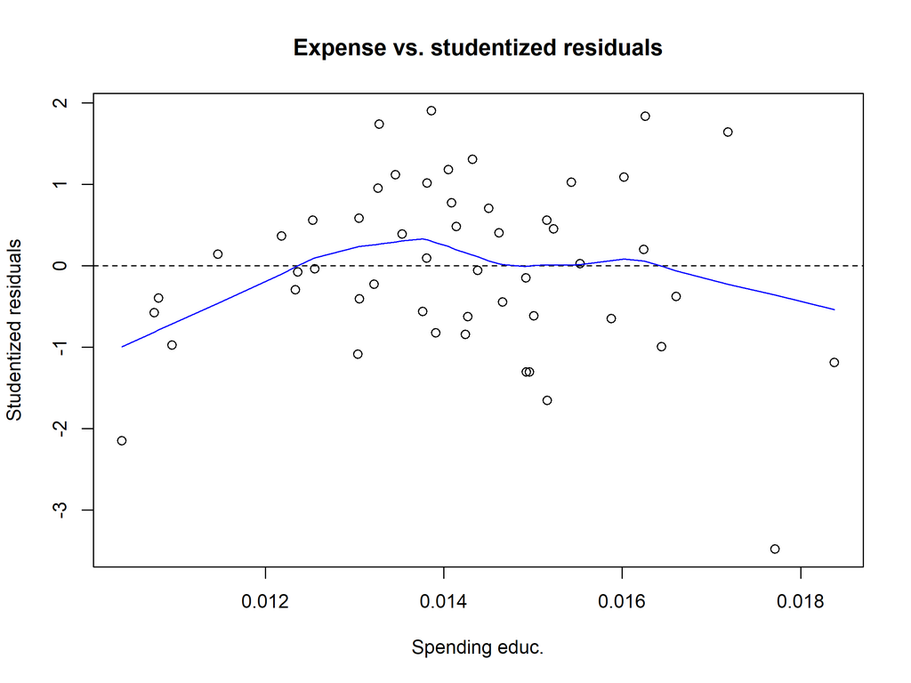

```r
plot(df_sat$exp_sqr, studres(model3),
     xlab = "Spending educ.",
     ylab = "Studentized residuals",
     main = "Expense vs. studentized residuals")
abline(h = 0, lty = 2)
lines(lowess(df_sat$exp_sqr, studres(model3)), col = "blue")
```

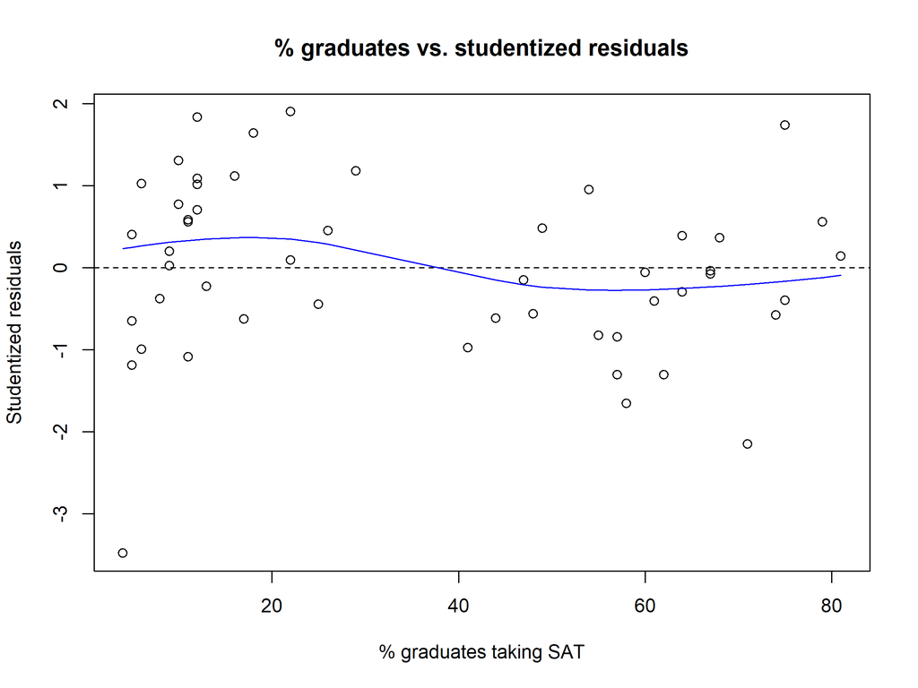

```r
plot(df_sat$percent, studres(model3),
     xlab = "% graduates taking SAT",
     ylab = "Studentized residuals",
     main = "% graduates vs. studentized residuals")
abline(h = 0, lty = 2)
lines(lowess(df_sat$percent, studres(model3)), col = "blue")
```

Finally, we check for normality in the residuals.

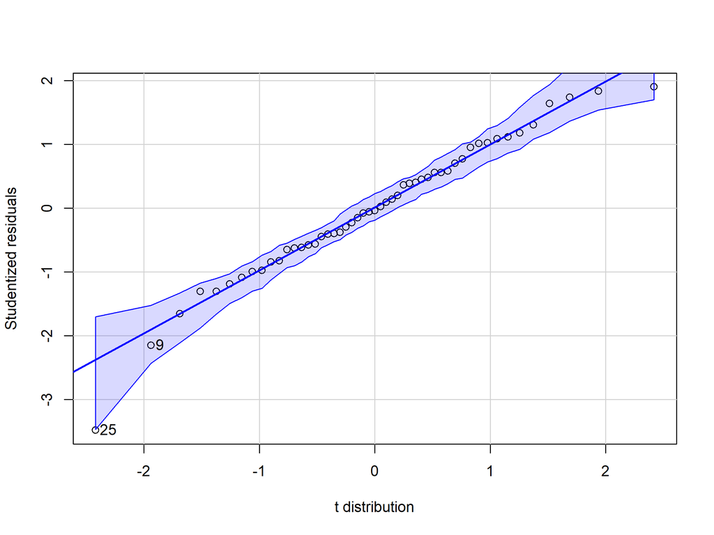

```
[1]  9 25
```

```r
qqPlot(model3,
       xlab = "t distribution",
       ylab = "Studentized residuals",
       id.method = "identify")
```

Not everything is perfect, but it might be as best as we can do under the circumstances.

# 11 Bonus: Unusual and influential data

We did not get a chance to talk properly about this topic during the lecture, but I am leaving the code here, as you may need it when you will cover the chapters in Fox (2008) on your own.

We can simply run the initial model, for SAT scores and expense on education, again.

```r
model1 <- lm(csat ~ exp_scale + per_scale + neast,
             data = df_sat,
             na.action = na.omit)
summary(model1)
```

```
Call:
lm(formula = csat ~ exp_scale + per_scale + neast, data = df_sat,
    na.action = na.omit)

Residuals:
    Min      1Q  Median      3Q     Max
-61.363 -19.619  -3.207  17.008  72.165

Coefficients:
              Estimate Std. Error t value Pr(>|t|)
(Intercept) 934.891177   5.114180 182.804  < 2e-16 ***
exp_scale     0.003477   0.004248   0.819  0.41718
per_scale    -2.856530   0.233554 -12.231 3.28e-16 ***
neast1       46.954995  15.606341   3.009  0.00421 **
---
Signif. codes:  0 '***' 0.001 '**' 0.01 '*' 0.05 '.' 0.1 ' ' 1

Residual standard error: 29.26 on 47 degrees of freedom
Multiple R-squared:  0.8203,    Adjusted R-squared:  0.8089
F-statistic: 71.53 on 3 and 47 DF,  p-value: < 2.2e-16
```

Let’s look at the relationship between expenditure and SAT score.

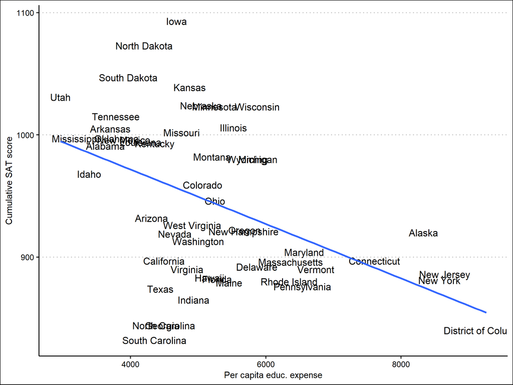

```r
ggplot(df_sat,
       aes(x = expense,
           y = csat,
           label = state)) +
    geom_text() +
    xlab("Per capita educ. expense") +
    ylab("Cumulative SAT score") +
    theme_clean() +
    geom_smooth(method = "lm",
                se = FALSE)
```

**Questions**:

1. How would you designate South Carolina, or Iowa? Are they outliers, or/and cases with high or low leverage? Are they influential cases or not?
2. How would you designate the District of Columbia? Is it an outlier, or/and an observation with high or low leverage? Is it an influential case or not?

## 11.1 Leverage

The `hatvalues()` function computes these hat values. Here, I add them to the data set.

```r
df_sat$hatv <- hatvalues(model1) # Store hat values in data frame
df_sat$row <- rownames(df_sat) # Create variable for row names, used in labeling points
```

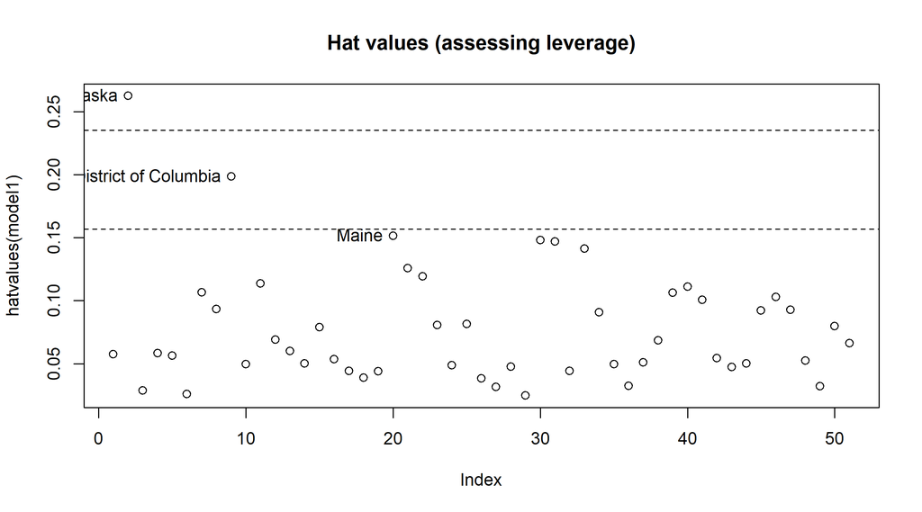

```r
plot(hatvalues(model1), # Plot the hat values
     main = "Hat values (assessing leverage)")
abline(h = c(2, 3) * 4 / length(df_sat$state), lty = 2) # Plot thresholds for hat values
with(subset(df_sat, df_sat$hatv >= 0.15),
     text(row, hatv, state, pos = 2)) # Label needed points
```

Remember, though, that for small samples, $3 \times$ average hat value is a better threshold than $2 \times$ average hat value.

## 11.2 Outliers

The `outlierTest()` function is available in the `car` package.

```r
outlierTest(model1)
```

```
No Studentized residuals with Bonferroni p < 0.05
Largest |rstudent|:
   rstudent unadjusted p-value Bonferroni p
16 2.698821          0.0096996      0.49468
```

Observation 16 is identified as perhaps a bit problematic (as long as no studentized residual has a Bonferroni $p < 0.05$, things are good), although the central message is that it’s not unusual to see such a residual in a sample as small as hours.

```r
df_sat[which(df_sat$row == 16), ]
```

```
   state  region     pop  area density metro waste energy toxic green csat vsat
16  Iowa Midwest 2777000 55875    49.7    44  0.83    333 14.65 24.16 1093  515
   msat percent expense income high college exp_scale per_scale neast   exp_sqr
16  578       5    4679 30.565 80.1    16.9 -556.9608 -30.76471     0 0.0146192
     inc_sqr  perc_sqr       hatv row
16 0.1808789 0.4472136 0.05341696  16
```

## 11.3 Influence

I will plot here only Cook’s *D*, although a few other measures, such as **DFBETA** and **DFBETAS** have been proposed.

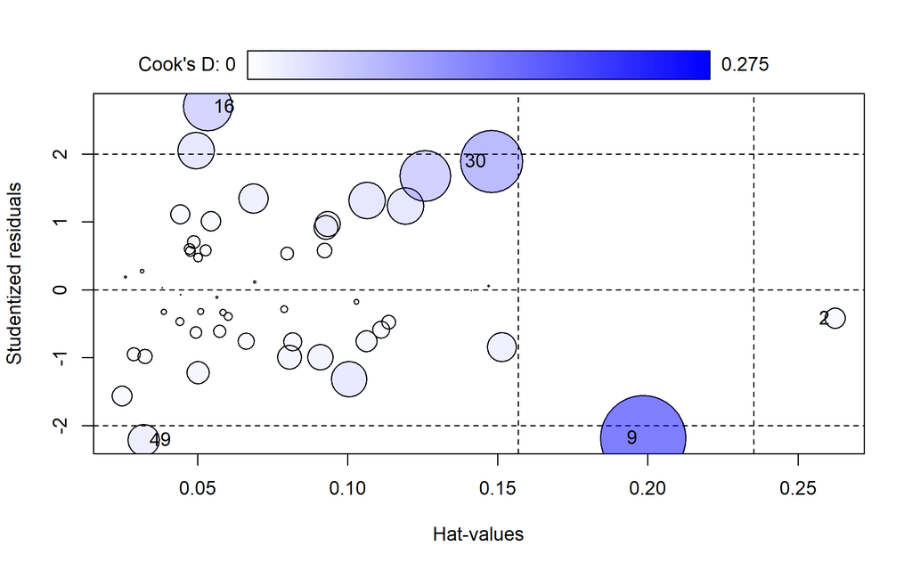

```
      StudRes        Hat      CookD
2  -0.4218008 0.26252074 0.01611507
9  -2.1897123 0.19847811 0.27465634
16  2.6988207 0.05341696 0.09063847
30  1.8902852 0.14803966 0.14716499
49 -2.2185781 0.03209272 0.03765770
```

```r
rownames(df_sat) <- df_sat$state
influencePlot(model1,
              xlab = "Hat-values",
              ylab = "Studentized residuals",
              id = list(method = "noteworthy"))
```

Because we specified “noteworthy” as a method, the function will use a set of pre-defined decision rules to label specific points in the plot that are worthy of inspection. If we had specified “identify” as a method, then the function would wait for you to click on the dots that you want labeled, and then for you to hit “Esc” when you’re done with labeling.

So which are those overlapping residuals?

```r
studres(model1)
```

```
          1           2           3           4           5           6
-0.61565063 -0.42180083 -0.95476728 -0.33398893 -0.11163705  0.18446181
          7           8           9          10          11          12
 1.31680657  0.96862728 -2.18971231 -0.62963013 -0.47779570  0.11558082
         13          14          15          16          17          18
-0.39138189  0.47510126 -0.28797817  2.69882066  1.11324901 -0.33025205
         19          20          21          22          23          24
-0.46984395 -0.84932044  1.68155100  1.23490929 -0.99350890  0.70437738
         25          26          27          28          29          30
-0.76338407  0.03102401  0.27162004  0.56310777 -1.56755655  1.89028523
         31          32          33          34          35          36
 0.05569051 -0.07309095 -0.01254645 -0.99010298  2.05395861 -0.98072728
         37          38          39          40          41          42
-0.32385679  1.34432679 -0.76143097 -0.59286339 -1.31811602  1.00689550
         43          44          45          46          47          48
 0.60086537 -1.21915789  0.57482511 -0.17807678  0.92152107  0.58343127
         49          50          51
-2.21857815  0.53593865 -0.76086611
```

```r
df_sat %>%
    filter(row %in% c(2, 9, 16, 30, 49)) %>%
    kable(caption = "5 problematic cases",
          caption.above = TRUE) %>%
    kable_styling(full_width = TRUE)
```

5 problematic cases

|  | state | region | pop | area | density | metro | waste | energy | toxic | green | csat | vsat | msat | percent | expense | income | high | college | exp_scale | per_scale | neast | exp_sqr | inc_sqr | perc_sqr | hatv | row |
| --- | --- | --- | --- | --- | --- | --- | --- | --- | --- | --- | --- | --- | --- | --- | --- | --- | --- | --- | --- | --- | --- | --- | --- | --- | --- | --- |
| Alaska | Alaska | West | 550000 | 570374 | 0.96 | 41.1 | 0.91 | 991 | 37.41 | NA | 920 | 439 | 481 | 41 | 8330 | 48.254 | 86.6 | 23.0 | 3094.0392 | 5.235294 | 0 | 0.0109566 | 0.1439572 | 0.1561738 | 0.2625207 | 2 |
| District of Columbia | District of Columbia | NA | NA | NA | NA | NA | NA | NA | NA | NA | 840 | 405 | 435 | 71 | 9259 | 35.807 | 73.1 | 33.3 | 4023.0392 | 35.235294 | 1 | 0.0103925 | 0.1671152 | 0.1186782 | 0.1984781 | 9 |
| Iowa | Iowa | Midwest | 2777000 | 55875 | 49.70 | 44.0 | 0.83 | 333 | 14.65 | 24.16 | 1093 | 515 | 578 | 5 | 4679 | 30.565 | 80.1 | 16.9 | -556.9608 | -30.764706 | 0 | 0.0146192 | 0.1808789 | 0.4472136 | 0.0534170 | 16 |
| New Hampshire | New Hampshire | N. East | 1109000 | 8969 | 123.65 | 56.1 | 0.99 | 224 | 7.48 | 14.62 | 921 | 440 | 481 | 75 | 5672 | 42.335 | 82.2 | 24.4 | 436.0392 | 39.235294 | 1 | 0.0132780 | 0.1536916 | 0.1154701 | 0.1480397 | 30 |
| West Virginia | West Virginia | South | 1793000 | 24087 | 74.44 | 36.4 | 0.95 | 415 | 21.30 | 51.14 | 926 | 441 | 485 | 17 | 4911 | 24.233 | 66.0 | 12.3 | -324.9608 | -18.764706 | 0 | 0.0142697 | 0.2031404 | 0.2425356 | 0.0320927 | 49 |

## 11.4 Addressing outliers

In terms of outliers and influential cases, Alaska, District of Columbia, and Iowa seem to consistently appear in the list of problematic observations.

```r
df_sat %>%
    filter(state %in% c("Alaska", "District of Columbia", "Iowa")) %>%
    kable(caption = "3 problematic cases",
          caption.above = TRUE) %>%
    kable_styling(full_width = TRUE)
```

3 problematic cases

|  | state | region | pop | area | density | metro | waste | energy | toxic | green | csat | vsat | msat | percent | expense | income | high | college | exp_scale | per_scale | neast | exp_sqr | inc_sqr | perc_sqr | hatv | row |
| --- | --- | --- | --- | --- | --- | --- | --- | --- | --- | --- | --- | --- | --- | --- | --- | --- | --- | --- | --- | --- | --- | --- | --- | --- | --- | --- |
| Alaska | Alaska | West | 550000 | 570374 | 0.96 | 41.1 | 0.91 | 991 | 37.41 | NA | 920 | 439 | 481 | 41 | 8330 | 48.254 | 86.6 | 23.0 | 3094.0392 | 5.235294 | 0 | 0.0109566 | 0.1439572 | 0.1561738 | 0.2625207 | 2 |
| District of Columbia | District of Columbia | NA | NA | NA | NA | NA | NA | NA | NA | NA | 840 | 405 | 435 | 71 | 9259 | 35.807 | 73.1 | 33.3 | 4023.0392 | 35.235294 | 1 | 0.0103925 | 0.1671152 | 0.1186782 | 0.1984781 | 9 |
| Iowa | Iowa | Midwest | 2777000 | 55875 | 49.70 | 44.0 | 0.83 | 333 | 14.65 | 24.16 | 1093 | 515 | 578 | 5 | 4679 | 30.565 | 80.1 | 16.9 | -556.9608 | -30.764706 | 0 | 0.0146192 | 0.1808789 | 0.4472136 | 0.0534170 | 16 |

At this point, in the course of a real project, you might consult the specifics of these three cases and see whether they are similar in terms of a factor that is not included in our model. That same factor might be a predictor of average SAT scores. Including it in the model might solve the problems.

A secondary strategy might be to remove these cases, and re-estimate the model. This should not be done automatically, though, but rather after some reflection as to whether this is the best course of action.

```r
df_sat %<>%
    filter(!(state %in% c("Alaska", "District of Columbia", "Iowa")))
model3 <- lm(csat ~ exp_scale + per_scale + neast,
             data = df_sat,
             na.action = na.omit)
summary(model3)
```

```
Call:
lm(formula = csat ~ exp_scale + per_scale + neast, data = df_sat,
    na.action = na.omit)

Residuals:
    Min      1Q  Median      3Q     Max
-60.618 -19.705  -3.178  20.298  60.909

Coefficients:
              Estimate Std. Error t value Pr(>|t|)
(Intercept) 935.991677   4.946989 189.204  < 2e-16 ***
exp_scale     0.008063   0.004740   1.701  0.09596 .
per_scale    -2.837607   0.216938 -13.080  < 2e-16 ***
neast1       43.750524  14.930593   2.930  0.00535 **
---
Signif. codes:  0 '***' 0.001 '**' 0.01 '*' 0.05 '.' 0.1 ' ' 1

Residual standard error: 26.38 on 44 degrees of freedom
Multiple R-squared:  0.8391,    Adjusted R-squared:  0.8282
F-statistic: 76.51 on 3 and 44 DF,  p-value: < 2.2e-16
```

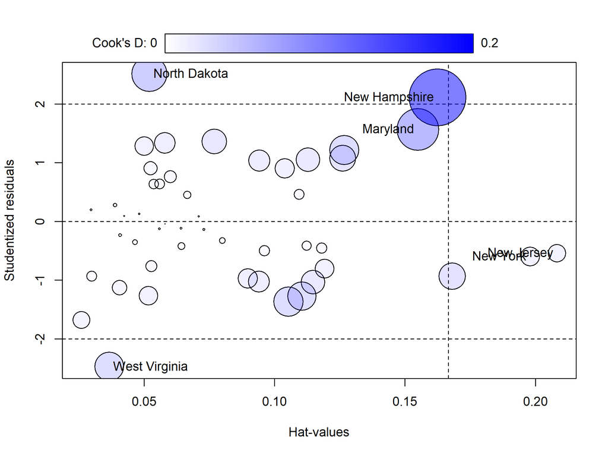

```
                 StudRes        Hat      CookD
Maryland       1.5674665 0.15490840 0.10898333
New Hampshire  2.1108460 0.16252519 0.20043177
New Jersey    -0.5380070 0.20826793 0.01934776
New York      -0.5987131 0.19797064 0.02244745
North Dakota   2.5098004 0.05205968 0.07718849
West Virginia -2.4731378 0.03663302 0.05208871
```

```r
influencePlot(model3,
              xlab = "Hat-values",
              ylab = "Studentized residuals",
              id = list(method = "noteworthy"))
```

# 12 Package versions